# Running BANKSY with Seurat

Compiled: May 25, 2026

## Introduction

In this vignette, we describe how to run BANKSY with Seurat objects. If you use BANKSY in your research, please cite

> *BANKSY unifies cell typing and tissue domain segmentation for scalable spatial omics data analysis*

> Vipul Singhal, Nigel Chou, Joseph Lee, Yifei Yue, Jinyue Liu, Wan Kee Chock, Li Lin, Yun-Ching Chang, Erica Mei Ling Teo, Jonathan Aow, Hwee Kuan Lee, Kok Hao Chen & Shyam Prabhakar

> Nature Genetics, 2024

> doi: 10.1038/s41588-024-01664-3

> Website: https://prabhakarlab.github.io/Banksy

BANKSY is a method that incorporates neighborhood information for clustering spatial omics data. By doing so, BANKSY is able to

- improve cell-type assignment in noisy data
- distinguish subtly different cell-types stratified by microenvironment
- identify spatial domains sharing the same microenvironment

The amount of neighborhood information incorporated is controlled by a parameter `lambda` in [0,1], with higher values giving more weight to the neighbourhood information during clustering.

## Overview

The `RunBanksy` function implemented with the *SeuratWrappers* package allows users to run BANKSY with Seurat objects. We describe two options of running `RunBanksy`. The first is within Seurat’s spatial framework (see [here](https://satijalab.org/seurat/articles/spatial_vignette.html) and [here](https://satijalab.org/seurat/articles/spatial_vignette_2.html)) and requires a Seurat object and a lambda parameter as mandatory input. The second option works with Seurat objects that do not have spatial information stored within, and therefore requires an additional argument giving the locations of the cell centroids or spots.

**Caveat**: `ScaleData` should not be run after a call to `RunBanksy`; `RunBanksy` populates the `scale.data` slot with the scaled BANKSY matrix. Calling `ScaleData` after `RunBanksy` performs gene-wise z-scaling, negating the effect of `lambda`.

Prerequisites to install:

- [Seurat](https://satijalab.org/seurat/install)
- [SeuratData](https://github.com/satijalab/seurat-data)
- [SeuratWrappers](https://github.com/satijalab/seurat-wrappers)
- [Banksy](https://github.com/prabhakarlab/Banksy/)

```r
library(Banksy)
library(Seurat)
library(SeuratData)
library(SeuratWrappers)

library(ggplot2)
library(gridExtra)
library(pals)

# Kelly palette for visualization
mypal <- kelly()[-1]
```

## Running BANKSY within Seurat’s spatial framework

We demonstrate how to run BANKSY within Seurat’s spatial analysis framework with a mouse hippocampus Slide-seq v2 dataset from the *SeuratData* package.

After installing *SeuratData*, the data can be accessed as follows:

```r
InstallData('ssHippo')
ss.hippo <- LoadData("ssHippo")
```

We perform simple preprocessing by filtering beads with high mito percentage and keeping only beads within the 5th and 98th percentile of total UMI counts. To keep runtime of this vignette short, we downsample the data to 10,000 beads.

```r
# Filtering
ss.hippo[['percent.mt']] <- PercentageFeatureSet(ss.hippo, pattern = '^MT-')
ss.hippo <- subset(ss.hippo, percent.mt < 10 &
                    nCount_Spatial > quantile(ss.hippo$nCount_Spatial, 0.05) &
                    nCount_Spatial < quantile(ss.hippo$nCount_Spatial, 0.98))
# Downsample
set.seed(42)
ss.hippo <- ss.hippo[,sample(colnames(ss.hippo), 1e4)]
```

Next, normalize the data and find variable genes:

```r
# Normalize
ss.hippo <- NormalizeData(ss.hippo)
ss.hippo <- FindVariableFeatures(ss.hippo)
ss.hippo <- ScaleData(ss.hippo)
```

To run BANKSY, we specify the following:

- `lambda`: a numeric value in [0,1]. With low values of lambda, BANKSY operates in cell-typing mode, while high values of lambda find spatial domains.
- `assay` and `slot`: determines where to pull the expression data from
- `features`: specifies features for downstream analysis. This can be `'all'`, `'variable'` or a subset of features.
- `k_geom`: the number of neighbors that defines a cell’s neighborhood

Call `?RunBanksy` for more details on function parameters.

```r
# Run BANKSY
ss.hippo <- RunBanksy(ss.hippo, lambda = 0.2, verbose=TRUE,
                      assay = 'Spatial', slot = 'data', features = 'variable',
                      k_geom = 15)
ss.hippo
```

```
## An object of class Seurat
## 27264 features across 10000 samples within 2 assays
## Active assay: BANKSY (4000 features, 0 variable features)
##  2 layers present: data, scale.data
##  1 other assay present: Spatial
##  1 image present: image
```

Note that the `RunBanksy` function sets the default assay to `BANKSY` ( determined by the `assay_name` argument) and fills the `scale.data` slot. Users should not call `ScaleData` on the `BANKSY` assay as this negates the effects of `lambda`.

The rest of the pipeline is similar to the ‘default’ Seurat pipline. We scale the data and run dimensionality reduction with PCA and UMAP:

```r
# Run PCA and UMAP
ss.hippo <- RunPCA(ss.hippo, assay = 'BANKSY', features = rownames(ss.hippo), npcs = 30)
ss.hippo <- RunUMAP(ss.hippo, dims = 1:30)
```

Next, find BANKSY clusters:

```r
# Clustering
ss.hippo <- FindNeighbors(ss.hippo, dims = 1:30)
ss.hippo <- FindClusters(ss.hippo, resolution = 0.5)
```

```
## Modularity Optimizer version 1.3.0 by Ludo Waltman and Nees Jan van Eck
##
## Number of nodes: 10000
## Number of edges: 365658
##
## Running Louvain algorithm...
## Maximum modularity in 10 random starts: 0.9033
## Number of communities: 13
## Elapsed time: 0 seconds
```

Visualize the UMAP and Spatial plot:

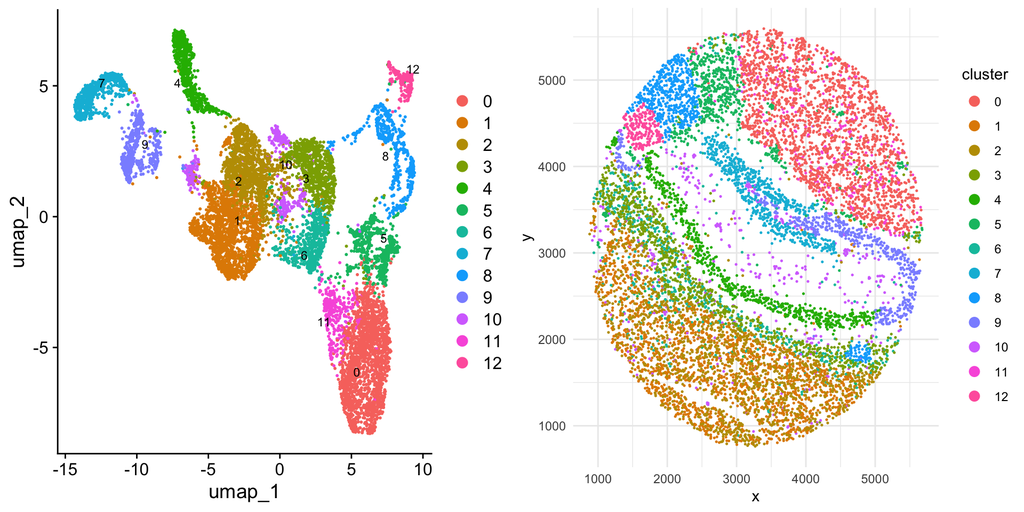

```r
# Viz
coords <- GetTissueCoordinates(ss.hippo)
coords$cluster <- Idents(ss.hippo)[coords$cells]
spatial_plot <- ggplot(coords, aes(x = x, y = y, color = cluster)) +
    geom_point(size = 0.25) + theme_minimal() +
    guides(color = guide_legend(override.aes = list(size = 3)))
grid.arrange(
    DimPlot(ss.hippo, pt.size = 0.25, label = TRUE, label.size = 3, repel = TRUE),
    spatial_plot,
    ncol = 2
)
```

Find markers based on the BANKSY clusters and visualize them. Here, we find differentially expressed genes between the CA1 and CA3 regions.

```r
# Find markers
DefaultAssay(ss.hippo) <- 'Spatial'
markers <- FindMarkers(ss.hippo, ident.1 = 4, ident.2 = 9, only.pos = F,
                       logfc.threshold = 1, min.pct = 0.5)
markers <- markers[markers$p_val_adj < 0.01,]
markers
```

|  | p_val | avg_log2FC | pct.1 | pct.2 | p_val_adj |
| --- | --- | --- | --- | --- | --- |
| SNAP25 | 0 | -1.260312 | 0.658 | 0.823 | 0e+00 |
| CHGB | 0 | -1.985343 | 0.439 | 0.697 | 0e+00 |
| STMN2 | 0 | -1.430138 | 0.335 | 0.574 | 0e+00 |
| SYN2 | 0 | -1.609355 | 0.332 | 0.564 | 0e+00 |
| ATP2B1 | 0 | 1.251540 | 0.639 | 0.474 | 0e+00 |
| CPLX2 | 0 | -1.220110 | 0.289 | 0.522 | 0e+00 |
| PRKCB | 0 | 1.394809 | 0.552 | 0.341 | 0e+00 |
| PCP4 | 0 | -1.269671 | 0.379 | 0.578 | 0e+00 |
| TUBB2A | 0 | -1.054176 | 0.450 | 0.629 | 0e+00 |
| DDN | 0 | 1.401976 | 0.592 | 0.396 | 0e+00 |
| SNCA | 0 | -1.022314 | 0.397 | 0.544 | 2e-07 |

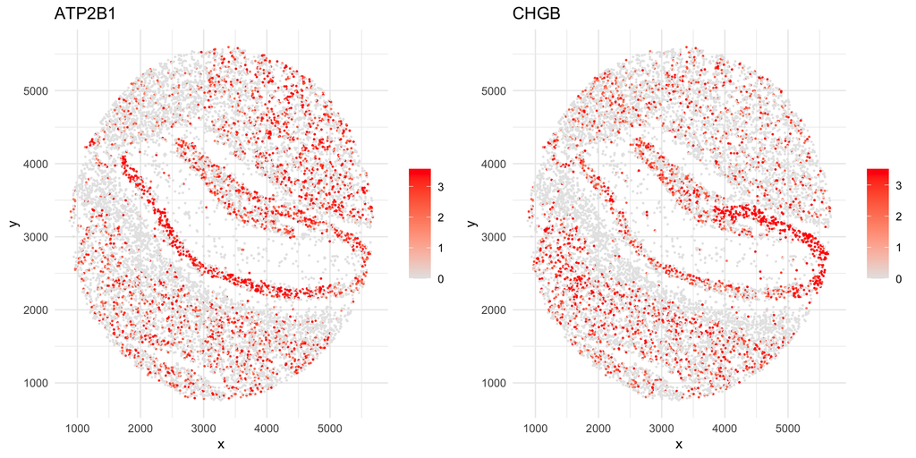

```r
genes <- c('ATP2B1', 'CHGB')
coords <- GetTissueCoordinates(ss.hippo)
gene_plots <- lapply(genes, function(g) {
    val <- GetAssayData(ss.hippo, assay = 'Spatial', layer = 'data')[g, coords$cells]
    val[val > quantile(val, 0.95)] <- quantile(val, 0.95)
    coords$expr <- val
    ggplot(coords, aes(x = x, y = y, color = expr)) +
        geom_point(size = 0.25) + theme_minimal() +
        scale_color_gradient(low = 'grey90', high = 'red') +
        ggtitle(g) + theme(legend.title = element_blank())
})
grid.arrange(grobs = gene_plots, ncol = 2)
```

## Running BANKSY with locations provided explicitly

One can also call `RunBanksy` on a Seurat object created from counts by providing the location of cell centroids or spots explicitly. In this case, the locations must be stored as metadata. Here, we use a mouse hippocampus VeraFISH dataset provided with the *Banksy* package.

```r
data(hippocampus)
head(hippocampus$expression[,1:5])
```

```
##         cell_1276 cell_8890 cell_691 cell_396 cell_9818
## Sparcl1        45         0       11       22         0
## Slc1a2         17         0        6        5         0
## Map            10         0       12       16         0
## Sqstm1         26         0        0        2         0
## Atp1a2          0         0        4        3         0
## Tnc             0         0        0        0         0
```

```r
head(hippocampus$locations)
```

|  | sdimx | sdimy |
| --- | --- | --- |
| cell_1276 | -13372.899 | 15776.37 |
| cell_8890 | 8941.101 | 15866.37 |
| cell_691 | -14882.899 | 15896.37 |
| cell_396 | -15492.899 | 15835.37 |
| cell_9818 | 11308.101 | 15846.37 |
| cell_11310 | 14894.101 | 15810.37 |

Construct the Seurat object by storing the locations of cell centroids as metadata. We keep cells with total count between 5th and 98th percentile:

```r
# Create manually
vf.hippo <- CreateSeuratObject(counts = hippocampus$expression,
                               meta.data = hippocampus$locations)
vf.hippo <- subset(vf.hippo,
                   nCount_RNA > quantile(vf.hippo$nCount_RNA, 0.05) &
                   nCount_RNA < quantile(vf.hippo$nCount_RNA, 0.98))
```

Next, we normalize the data by library size and scale the data:

```r
# Normalize
vf.hippo <- NormalizeData(vf.hippo, scale.factor = 100, normalization.method = 'RC')
vf.hippo <- ScaleData(vf.hippo)
```

Now, run BANKSY. Here, we provide the column names of the x and y spatial coordinates as stored in the metadata to `dimx` and `dimy` respectively:

```r
# Run BANKSY
vf.hippo <- RunBanksy(vf.hippo, lambda = 0.2, dimx = 'sdimx', dimy = 'sdimy',
                      assay = 'RNA', slot = 'data', features = 'all', k_geom = 10)
```

Note that the `RunBanksy` function sets the default assay to `BANKSY` ( determined by the `assay_name` argument) and fills the `scale.data` slot. Users should not call `ScaleData` on the `BANKSY` assay as this negates the effects of `lambda`.

Run PCA on the BANKSY matrix:

```r
# PCA
vf.hippo <- RunPCA(vf.hippo, assay = 'BANKSY', features = rownames(vf.hippo), npcs = 20)
```

Find BANKSY clusters:

```r
# Cluster
vf.hippo <- FindNeighbors(vf.hippo, dims = 1:20)
vf.hippo <- FindClusters(vf.hippo, resolution = 0.5)
```

```
## Modularity Optimizer version 1.3.0 by Ludo Waltman and Nees Jan van Eck
##
## Number of nodes: 10205
## Number of edges: 446178
##
## Running Louvain algorithm...
## Maximum modularity in 10 random starts: 0.9099
## Number of communities: 15
## Elapsed time: 0 seconds
```

Visualise BANKSY clusters in spatial dimensions:

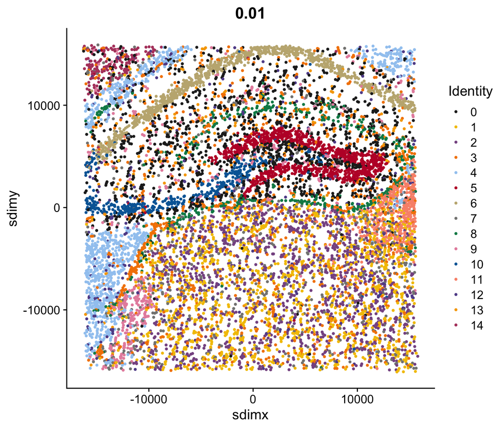

```r
# Viz
FeatureScatter(vf.hippo, 'sdimx', 'sdimy', cols = mypal, pt.size = 0.75)
```

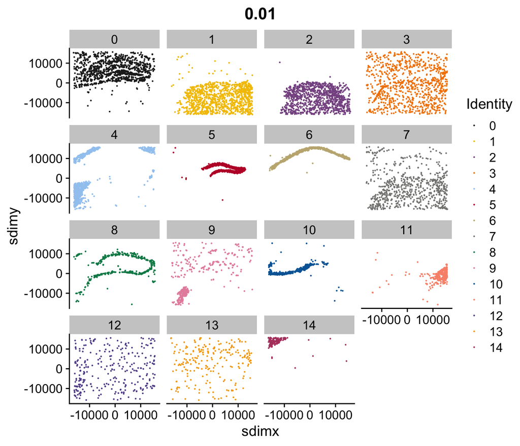

```r
FeatureScatter(vf.hippo, 'sdimx', 'sdimy', cols = mypal, pt.size = 0.1) + facet_wrap(~ colors)
```

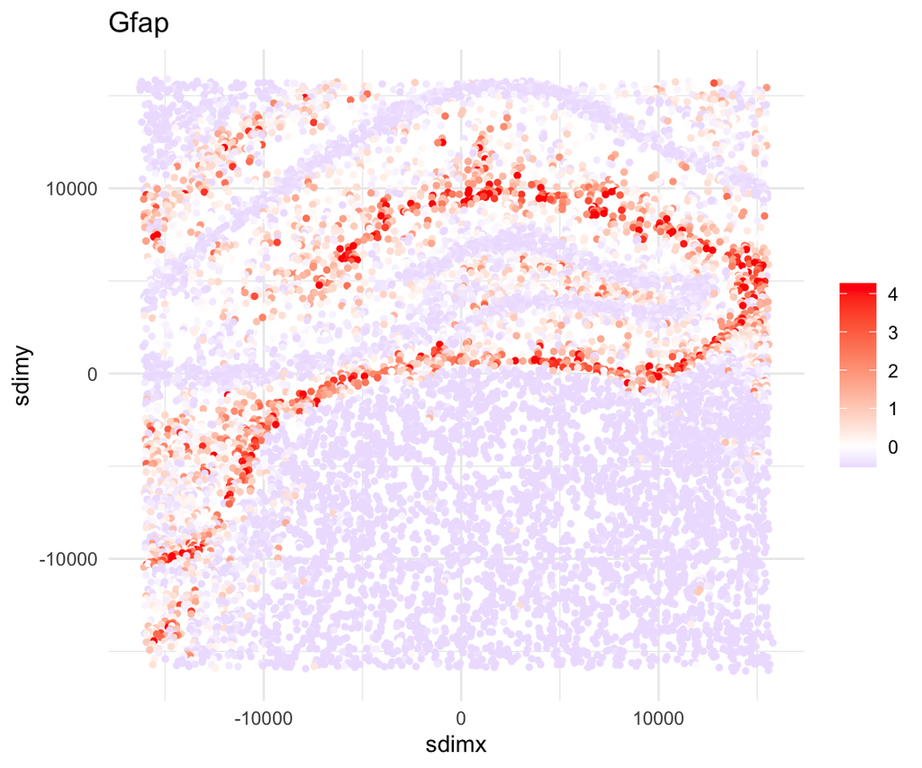

```r
# Find markers
DefaultAssay(vf.hippo) <- 'RNA'
markers <- FindMarkers(vf.hippo, ident.1 = 6, only.pos = TRUE)

genePlot <- function(object, dimx, dimy, gene, assay = 'RNA',
                     layer = 'scale.data', q.low = 0.01, q.high = 0.99,
                     col.low='blue', col.high='red') {
    val <- GetAssayData(object, assay=assay, layer=layer)[gene,]
    val.low <- quantile(val, q.low)
    val.high <- quantile(val, q.high)
    val[val < val.low] <- val.low
    val[val > val.high] <- val.high
    pdf <- data.frame(x=object[[dimx]], y=object[[dimy]], gene=val)
    colnames(pdf) <- c('sdimx','sdimy', 'gene')
    ggplot(pdf, aes(x=sdimx,y=sdimy,color=gene)) + geom_point(size = 1) +
        theme_minimal() + theme(legend.title = element_blank()) +
        scale_color_gradient2(low = col.low, high = col.high) +
        ggtitle(gene)
}

genePlot(vf.hippo, 'sdimx', 'sdimy', 'Gfap')
```

## Multi-sample analysis

This section demonstrate demonstrates multi-sample analysis. Such an approach is appropriate when analysing multiple spatial omics datasets with non-contiguous spatial coordinates, and when large batch effects are not present.

Here, we use a mouse hippocampus VeraFISH dataset provided with the *Banksy* package.

```r
data(hippocampus)
head(hippocampus$expression[,1:5])
```

```
##         cell_1276 cell_8890 cell_691 cell_396 cell_9818
## Sparcl1        45         0       11       22         0
## Slc1a2         17         0        6        5         0
## Map            10         0       12       16         0
## Sqstm1         26         0        0        2         0
## Atp1a2          0         0        4        3         0
## Tnc             0         0        0        0         0
```

```r
head(hippocampus$locations)
```

|  | sdimx | sdimy |
| --- | --- | --- |
| cell_1276 | -13372.899 | 15776.37 |
| cell_8890 | 8941.101 | 15866.37 |
| cell_691 | -14882.899 | 15896.37 |
| cell_396 | -15492.899 | 15835.37 |
| cell_9818 | 11308.101 | 15846.37 |
| cell_11310 | 14894.101 | 15810.37 |

For demonstration purposes, we create three separate datasets by splitting the data.

```r
# Number of groups
n_groups = 3
group_names = paste0('group', seq(n_groups))
group_size = 1000
starts = seq(1, by=group_size, length.out=n_groups)
ends = starts + group_size - 1

# List of Seurat objects
seu_list = lapply(seq(n_groups), function(i) {
  idx = seq(starts[i], ends[i])
  seu = CreateSeuratObject(
    counts = hippocampus$expression[,idx],
    meta.data = data.frame(scale(hippocampus$locations[idx,], scale = FALSE))
  )
  # Set original identity of cell
  seu$orig.ident = group_names[i]
  seu
})
seu_list
```

```
## [[1]]
## An object of class Seurat
## 120 features across 1000 samples within 1 assay
## Active assay: RNA (120 features, 0 variable features)
##  1 layer present: counts
##
## [[2]]
## An object of class Seurat
## 120 features across 1000 samples within 1 assay
## Active assay: RNA (120 features, 0 variable features)
##  1 layer present: counts
##
## [[3]]
## An object of class Seurat
## 120 features across 1000 samples within 1 assay
## Active assay: RNA (120 features, 0 variable features)
##  1 layer present: counts
```

Perform normalisation for each dataset.

```r
seu_list = lapply(seu_list, NormalizeData,
                  scale.factor = 100, normalization.method = 'RC')
```

Merge the datasets. Note that the spatial coordinates overlap.

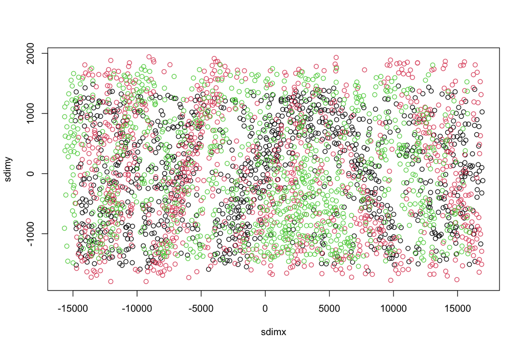

```r
# Merge
seu = Reduce(merge, seu_list)
seu = JoinLayers(seu) # run this for Seurat v5 objects

# Plot spatial coordinates colored by group
plot(FetchData(seu, c('sdimx', 'sdimy')), col = factor(seu$orig.ident))
```

Now run BANKSY. For multi-sample analysis, the argument `group` must be provided, which specifies the name of the metadata column that gives the assignment of each cell or spot to its original Seurat object. Here, we use `orig.ident`. Internally, providing the `group` argument tells the function to compute neighborhood matrices based on locations staggered by `group`, ensuring that cells from different spatial datasets do not overlap. The staggered locations are stored in the metadata for sanity checking. The `split.scale` argument allows for within-group scaling, accounting for minor differences in datasets.

```r
# Grouping variable
head(seu@meta.data)
```

|  | orig.ident | nCount_RNA | nFeature_RNA | sdimx | sdimy |
| --- | --- | --- | --- | --- | --- |
| cell_1276 | group1 | 266 | 51 | -11933.19 | 1366.934 |
| cell_8890 | group1 | 13 | 3 | 10380.81 | 1456.934 |
| cell_691 | group1 | 132 | 36 | -13443.19 | 1486.934 |
| cell_396 | group1 | 95 | 27 | -14053.19 | 1425.934 |
| cell_9818 | group1 | 10 | 5 | 12747.81 | 1436.934 |
| cell_11310 | group1 | 15 | 5 | 16333.81 | 1400.934 |

```r
table(seu$orig.ident)
```

```
##
## group1 group2 group3
##   1000   1000   1000
```

```r
# Run BANKSY
seu = RunBanksy(seu, lambda = 0.2, assay = 'RNA', slot = 'data',
                dimx = 'sdimx', dimy = 'sdimy', features = 'all',
                group = 'orig.ident', split.scale = TRUE, k_geom = 15)

# Staggered locations added to metadata
head(seu@meta.data)
```

|  | orig.ident | nCount_RNA | nFeature_RNA | sdimx | sdimy | staggered_sdimx | staggered_sdimy |
| --- | --- | --- | --- | --- | --- | --- | --- |
| cell_1276 | group1 | 266 | 51 | -11933.19 | 1366.934 | 3728.686 | 1366.934 |
| cell_8890 | group1 | 13 | 3 | 10380.81 | 1456.934 | 26042.686 | 1456.934 |
| cell_691 | group1 | 132 | 36 | -13443.19 | 1486.934 | 2218.686 | 1486.934 |
| cell_396 | group1 | 95 | 27 | -14053.19 | 1425.934 | 1608.686 | 1425.934 |
| cell_9818 | group1 | 10 | 5 | 12747.81 | 1436.934 | 28409.686 | 1436.934 |
| cell_11310 | group1 | 15 | 5 | 16333.81 | 1400.934 | 31995.686 | 1400.934 |

The rest of the workflow follows as before:

```r
seu = RunPCA(seu, assay = 'BANKSY', features = rownames(seu), npcs = 30)
seu = RunUMAP(seu, dims = 1:30)
seu = FindNeighbors(seu, dims = 1:30)
seu = FindClusters(seu, resolution = 1)
```

```
## Modularity Optimizer version 1.3.0 by Ludo Waltman and Nees Jan van Eck
##
## Number of nodes: 3000
## Number of edges: 171757
##
## Running Louvain algorithm...
## Maximum modularity in 10 random starts: 0.8094
## Number of communities: 12
## Elapsed time: 0 seconds
```

Visualise clusters:

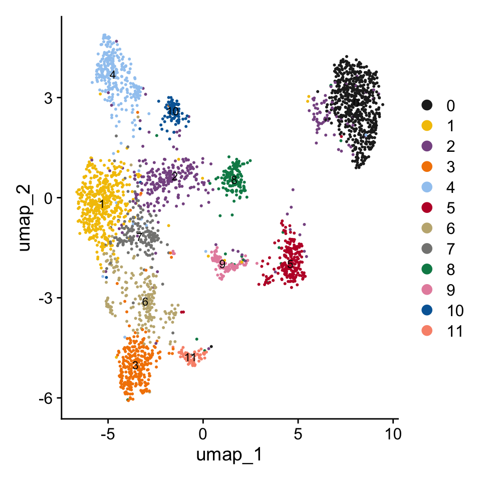

```r
mypal <- kelly()[-1]
DimPlot(seu, pt.size = 0.25, label = TRUE, label.size = 3, cols = mypal)
```

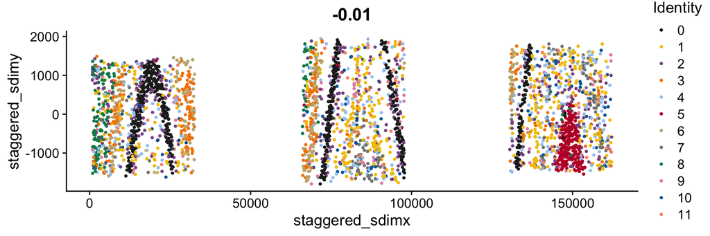

```r
FeatureScatter(seu, 'staggered_sdimx', 'staggered_sdimy', pt.size = 0.75, cols = mypal)
```

## Spatial data integration with Harmony

BANKSY can be used with Harmony for integrating multiple spatial omics datasets in the presence of strong batch effects.

Download the data.

```r
library(spatialLIBD)
library(ExperimentHub)
library(harmony)

ehub <- ExperimentHub::ExperimentHub()
spe <- spatialLIBD::fetch_data(type = "spe", eh = ehub)

imgData(spe) <- NULL
assay(spe, "logcounts") <- NULL
reducedDims(spe) <- NULL
rowData(spe) <- NULL
colData(spe) <- DataFrame(
  sample_id = spe$sample_id,
  clust_annotation = factor(
    addNA(spe$layer_guess_reordered_short),
    exclude = NULL, labels = seq(8)
  ),
  in_tissue = spe$in_tissue,
  row.names = colnames(spe)
)
invisible(gc())

# Subset to first sample of each subject
sample_names <- c("151507", "151669", "151673")
spe_list <- lapply(sample_names, function(x) spe[, spe$sample_id == x])
rm(spe)
invisible(gc())
```

Normalise the data and compute highly variable features.

```r
# Convert to Seurat and Normalize data
seu_list <- lapply(spe_list, function(x) {
  x <- as.Seurat(x, data = NULL)
  NormalizeData(x, scale.factor = 3000, normalization.method = 'RC')
})

# Compute HVGs for each dataset and take the union
hvgs <- lapply(seu_list, function(x) {
  VariableFeatures(FindVariableFeatures(x, nfeatures = 2000))
})
hvgs <- Reduce(union, hvgs)

# Subset to HVGs
seu_list <- lapply(seu_list, function(x) x[hvgs,])
seu <- Reduce(merge, seu_list)

locs <- do.call(rbind.data.frame, lapply(spe_list, spatialCoords))
seu@meta.data <- cbind(seu@meta.data, locs)

seu
```

```
## An object of class Seurat
## 4467 features across 11526 samples within 1 assay
## Active assay: originalexp (4467 features, 0 variable features)
##  2 layers present: counts, data
```

Run BANKSY. When analysing multiple samples, the argument `group` must be provided, which specifies the name of the metadata column that gives the assignment of each cell or spot to its original Seurat object. Here, we use `sample_id`. Internally, providing the `group` argument tells the function to compute neighborhood matrices based on locations staggered by `group`, ensuring that cells from different spatial datasets do not overlap. The staggered locations are stored in the metadata for sanity checking. Within-group scaling has little effect in the presence of strong batch effects, hence, we set `split.scale=FALSE` for efficiency.

```r
# Grouping variable
head(seu@meta.data)
```

|  | orig.ident | nCount_originalexp | nFeature_originalexp | sample_id | clust_annotation | in_tissue | pxl_col_in_fullres | pxl_row_in_fullres |
| --- | --- | --- | --- | --- | --- | --- | --- | --- |
| AAACAACGAATAGTTC-1_1 | SeuratProject | 288 | 197 | 151507 | 1 | TRUE | 3276 | 2514 |
| AAACAAGTATCTCCCA-1_1 | SeuratProject | 1546 | 550 | 151507 | 3 | TRUE | 9178 | 8520 |
| AAACAATCTACTAGCA-1_1 | SeuratProject | 525 | 247 | 151507 | 1 | TRUE | 5133 | 2878 |
| AAACACCAATAACTGC-1_1 | SeuratProject | 1123 | 457 | 151507 | 7 | TRUE | 3462 | 9581 |
| AAACAGCTTTCAGAAG-1_1 | SeuratProject | 1008 | 415 | 151507 | 6 | TRUE | 2779 | 7663 |
| AAACAGGGTCTATATT-1_1 | SeuratProject | 1431 | 539 | 151507 | 6 | TRUE | 3053 | 8143 |

```r
table(seu$sample_id)
```

```
##
## 151507 151669 151673
##   4226   3661   3639
```

```r
sdimx <- 'pxl_col_in_fullres'
sdimy <- 'pxl_row_in_fullres'

# Run BANKSY
seu <- RunBanksy(seu, lambda = 0.2, assay = 'originalexp', slot = 'data',
                dimx = sdimx, dimy = sdimy, features = 'all',
                group = 'sample_id', split.scale = FALSE, k_geom = 6)
```

Compute a spatially-aware embedding with PCA on the BANKSY matrix, and run Harmony on this embedding.

```r
seu <- RunPCA(seu, assay = 'BANKSY', features = rownames(seu), npcs = 10)
seu <- RunHarmony(seu, group.by.vars='sample_id')
```

The rest of the workflow follows as before:

```r
seu <- RunUMAP(seu, dims = 1:10, reduction = 'harmony')
seu <- FindNeighbors(seu, dims = 1:10, reduction = 'harmony')
seu <- FindClusters(seu, resolution = 0.4)
```

```
## Modularity Optimizer version 1.3.0 by Ludo Waltman and Nees Jan van Eck
##
## Number of nodes: 11526
## Number of edges: 377720
##
## Running Louvain algorithm...
## Maximum modularity in 10 random starts: 0.8798
## Number of communities: 6
## Elapsed time: 1 seconds
```

Visualise clusters:

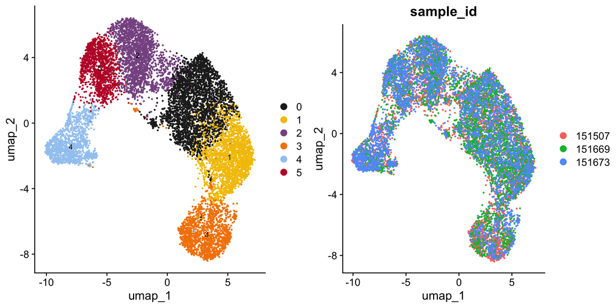

```r
grid.arrange(
    DimPlot(seu, pt.size = 0.25, label = TRUE, label.size = 3, cols = mypal),
    DimPlot(seu, pt.size = 0.25, group.by = 'sample_id'),
    ncol = 2
)
```

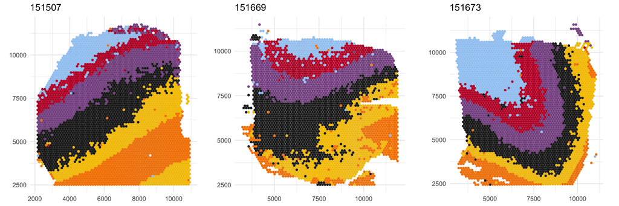

```r
spatial_plots <- lapply(sample_names, function(s) {
    sub <- subset(seu, sample_id == s)
    ggplot(sub@meta.data, aes(x = pxl_col_in_fullres, y = pxl_row_in_fullres,
                              color = seurat_clusters)) +
        geom_point(size = 1) + coord_equal() + theme_minimal() +
        scale_color_manual(values = mypal) +
        ggtitle(s) + theme(legend.position = 'none') +
        labs(x = NULL, y = NULL)
})
grid.arrange(grobs = spatial_plots, ncol = 3)
```

## Scaling to large datasets

For large datasets (millions of cells), materializing the full BANKSY matrix can exceed memory limits. The `lazy` option in `RunBanksy` avoids this by computing PCs of the BANKSY matrix directly via a lazy linear operator. The BANKSY matrix is never formed; instead, matrix-vector products are evaluated on-the-fly using the sparse expression matrix and weight matrix. This reduces peak memory from $O(\text{genes} \times \text{cells})$ (the dense BANKSY matrix) to $O(\text{nnz}(\text{input}))$ (the number of non-zero entries in the sparse input), since only the sparse input and sparse weight matrix are held in memory.

**Note**: `lazy=TRUE` currently supports M=0 only (no azimuthal Gabor filter). When `group` is specified, `split.scale=TRUE` applies within-group scaling in the lazy workflow as in the standard workflow.

This feature requires the development versions of Banksy and SeuratWrappers:

```r
devtools::install_github('prabhakarlab/Banksy@feat-sparse-matmul')
devtools::install_github('jleechung/seurat-wrappers@feat-sparse-matmul')
```

We demonstrate this with a 10X Xenium mouse brain dataset (~37k cells), performing domain segmentation with `lambda = 0.8`.

Download the dataset:

```r
download.file(
    url = 'https://cf.10xgenomics.com/samples/xenium/1.0.2/Xenium_V1_FF_Mouse_Brain_Coronal_Subset_CTX_HP/Xenium_V1_FF_Mouse_Brain_Coronal_Subset_CTX_HP_outs.zip',
    destfile = '~/Downloads/xenium_subset.zip'
)
unzip('~/Downloads/xenium_subset.zip', exdir = '~/Downloads/xenium_subset')
```

Load and preprocess:

```r
xenium <- LoadXenium('~/Downloads/xenium_subset', fov = 'fov')
xenium <- NormalizeData(xenium)
xenium <- FindVariableFeatures(xenium)
```

With `lazy = TRUE`, `RunBanksy` reads the expression matrix from the `data` slot of the `Xenium` assay, computes `npcs` principal components of the BANKSY matrix (default 50, matching Seurat’s `RunPCA`) directly via a sparse linear operator, and stores the result as a dimensionality reduction named by `assay_name`. No `BANKSY` assay is created, and there is no need to call `RunPCA` separately. For multi-sample integration, you can run Harmony with `project.dim = FALSE` on the BANKSY reduction before `FindNeighbors` (see the Harmony section above).

```r
xenium_input <- xenium
xenium <- RunBanksy(xenium, lazy = TRUE, npcs = 50,
                    lambda = 0.8, k_geom = 30, use_agf = FALSE,
                    assay = 'Xenium', slot = 'data', features = 'variable',
                    assay_name = 'BANKSY', verbose = TRUE)

# Optionally, run Harmony for batch correction
# xenium <- RunHarmony(xenium, group.by.vars = 'batch', reduction.use = 'BANKSY', project.dim = FALSE)

xenium <- FindNeighbors(xenium, reduction = 'BANKSY', dims = 1:50)
xenium <- FindClusters(xenium, resolution = 0.5)
```

```
## Modularity Optimizer version 1.3.0 by Ludo Waltman and Nees Jan van Eck
##
## Number of nodes: 36602
## Number of edges: 1017035
##
## Running Louvain algorithm...
## Maximum modularity in 10 random starts: 0.9441
## Number of communities: 23
## Elapsed time: 3 seconds
```

Visualize the spatial domains:

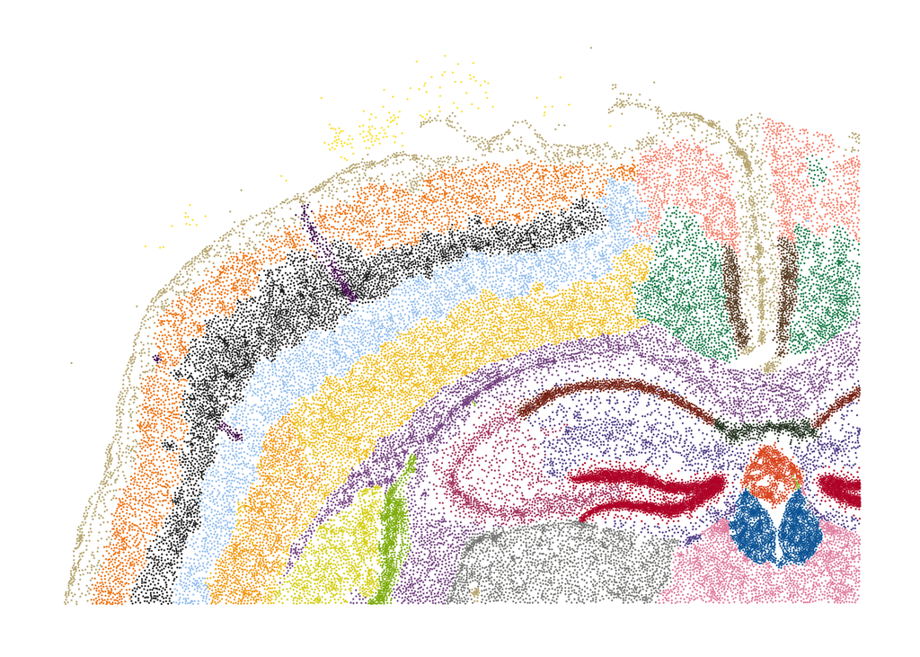

```r
n_clust <- length(levels(Idents(xenium)))
pal <- c(mypal, hcl.colors(max(0, n_clust - length(mypal))))
ImageDimPlot(xenium, size = 0.5, cols = pal) +
    coord_flip() + scale_x_reverse() + NoLegend() +
    theme(plot.background = element_rect(fill = 'white'),
          panel.background = element_rect(fill = 'white'))
```

**Equivalence with the standard workflow**

The standard workflow constructs the full BANKSY matrix `M` by vertically stacking the z-scored expression matrix and the z-scored neighborhood-smoothed matrix (weighted by `lambda`), where z-scoring includes clipping to [-10, 10] to match Seurat’s `FastRowScale`. PCA is then computed on `M` via `RunPCA`.

With `lazy=TRUE`, `M` is never formed. Instead, `irlba` accesses `M` through a lazy linear operator that evaluates matrix-vector products on the fly. The key insight is that `(XW)v = X(Wv)` by associativity: the sparse neighbor-weight matrix `W` is applied to the vector first, then left-multiplied by the sparse expression matrix `X`, avoiding formation of the dense product `XW`. Row means, standard deviations, and a sparse correction for z-score clipping are precomputed once before the Lanczos iterations begin.

The standard workflow materializes the full BANKSY matrix as a Seurat assay, then runs PCA via `RunPCA`:

```r
xenium_std <- RunBanksy(xenium_input, lambda = 0.8, verbose = TRUE,
                        assay = 'Xenium', slot = 'data', features = 'variable',
                        use_agf = FALSE, k_geom = 30)
xenium_std <- RunPCA(xenium_std, assay = 'BANKSY', features = rownames(xenium_std),
                     npcs = 50)
xenium_std <- FindNeighbors(xenium_std, dims = 1:50)
xenium_std <- FindClusters(xenium_std, resolution = 0.5)
```

```
## Modularity Optimizer version 1.3.0 by Ludo Waltman and Nees Jan van Eck
##
## Number of nodes: 36602
## Number of edges: 1016983
##
## Running Louvain algorithm...
## Maximum modularity in 10 random starts: 0.9441
## Number of communities: 23
## Elapsed time: 3 seconds
```

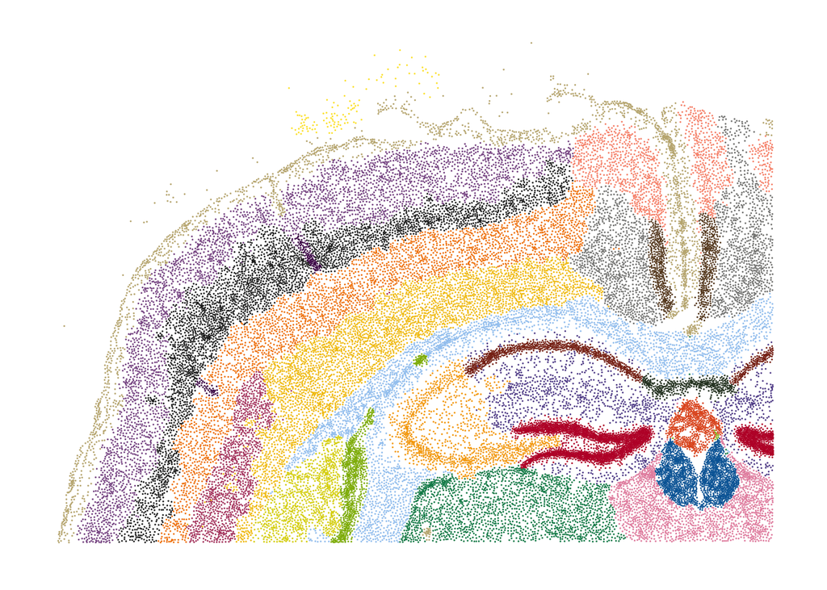

```r
n_clust <- length(levels(Idents(xenium_std)))
pal <- c(mypal, hcl.colors(max(0, n_clust - length(mypal))))
ImageDimPlot(xenium_std, size = 0.5, cols = pal) +
    coord_flip() + scale_x_reverse() + NoLegend() +
    theme(plot.background = element_rect(fill = 'white'),
          panel.background = element_rect(fill = 'white'))
```

We compare the two embeddings with three checks:

```r
U1 <- scale(Embeddings(xenium_std, 'pca'), scale = FALSE)
U2 <- scale(Embeddings(xenium, 'BANKSY'), scale = FALSE)
npcs <- ncol(U1)
```

**Subspace overlap.** Individual PCs may differ due to near-degenerate singular values, but the subspaces they span should be equivalent. We measure this via principal angles between the top-k subspaces from each path. A minimum cosine near 1 means the two subspaces are effectively identical:

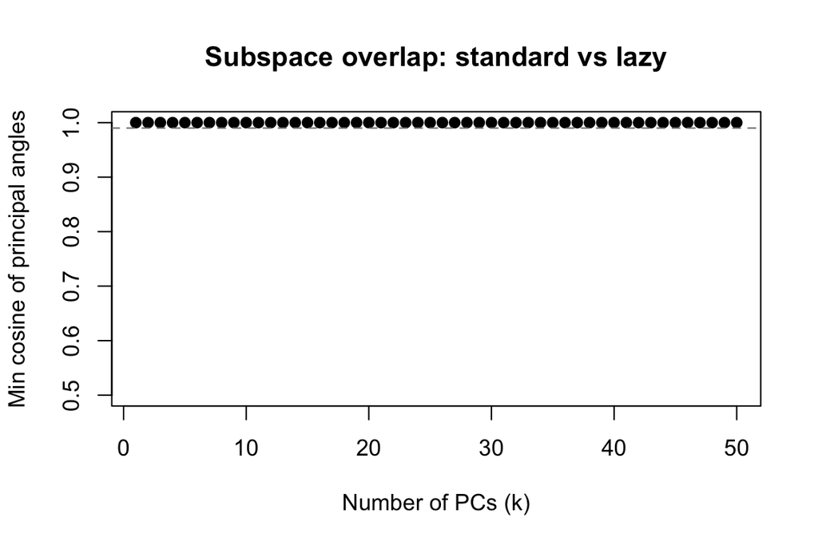

```r
Q1 <- qr.Q(qr(U1))
Q2 <- qr.Q(qr(U2))
subspace_cos <- sapply(seq_len(npcs), function(k) {
    min(svd(crossprod(Q1[, 1:k, drop = FALSE],
                      Q2[, 1:k, drop = FALSE]))$d)
})

plot(seq_len(npcs), subspace_cos, type = 'b', pch = 19, ylim = c(0.5, 1),
     xlab = 'Number of PCs (k)', ylab = 'Min cosine of principal angles',
     main = 'Subspace overlap: standard vs lazy')
abline(h = 0.99, lty = 2, col = 'grey50')
```

**kNN overlap.** Since clustering operates on the nearest-neighbor graph, we compare the 30-NN graphs built from each embedding. The mean Jaccard index measures what fraction of each cell’s neighbors are shared between the two paths:

```r
nn1 <- RANN::nn2(U1, k = 30)$nn.idx
nn2 <- RANN::nn2(U2, k = 30)$nn.idx
jaccard <- mean(sapply(seq_len(nrow(nn1)), function(i) {
    length(intersect(nn1[i,], nn2[i,])) / length(union(nn1[i,], nn2[i,]))
}))
cat('Mean kNN Jaccard overlap (k=30):', round(jaccard, 4), '\n')
```

```
## Mean kNN Jaccard overlap (k=30): 0.9999
```

**Clustering agreement.** The adjusted Rand index (ARI) measures how closely the two sets of cluster labels agree, adjusted for chance:

```r
ari <- mclust::adjustedRandIndex(
    as.integer(Idents(xenium_std)),
    as.integer(Idents(xenium))
)
cat('Adjusted Rand Index:', round(ari, 4), '\n')
```

```
## Adjusted Rand Index: 0.8503
```

## Getting help

For more information, visit https://github.com/prabhakarlab/Banksy.

**Vignette runtime**

```
## Time difference of 3.313371 mins
```